# Estimation & Troubleshooting Errors

```r
# install.packages('DiagrammeR')
# install.packages('lavaanPlot') install.packages('lavaan')
# install.packages('dplyr')
library(lavaan)
library(dplyr)
library(lavaanPlot)
```

```r
habit <- read.table("sem_categorical.dat", header = FALSE)
head(habit)  # Notice that there are no variable names in this dataset
```

```
##   V1 V2 V3 V4       V5       V6       V7       V8    V9 V10              V11
## 1 49  1  0  1 3.666667 3.333333 3.333333 3.416667 3.500 4.2             4.25
## 2 59  0  1  0 3.000000 4.333333 3.666667 3.250000 2.375 3.0              2.5
## 3 23  0  0  1 3.333333 3.666667 2.333333 3.000000 3.250 3.4              3.5
## 4 26  0  1  1 3.666667 4.666667 4.333333 3.500000 4.000 3.5                4
## 5 46  1  1  0 2.333333 3.000000 3.333333 2.916667 2.750 3.0 2.66666666666667
## 6 24  0  0  0 4.333333 3.666667 3.666667 4.083333 3.000 4.4             2.75
##                V12 V13 V14 V15 V16 V17 V18 V19 V20 V21 V22
## 1              3.6   2   1   2   2   2   2   1   2   2   2
## 2            3.375   3   3   1   2   2   3   3   1   3   1
## 3              3.8   1   3   2   2   2   2   1   1   2   1
## 4 2.66666666666667   3   3   1   2   1   3   1   3   2   3
## 5 3.77777777777778   3   3   3   2   3   3   1   1   2   3
## 6              4.8   2   3   2   2   2   1   1   1   2   2
```

This is a longer dataset than we used in the last lab, so we’ll add column names to the variables. Because we’re using the same dataset as the one for Mplus, missing values are still “.” At last line of code in this chunk tells R to turn all variables into numeric, which means that the “.” (which are character) will be turned into NAs - and that’s what we want.

There are other ways to do this, for example: habit[habit == “.”] <- NA. This version will convert only “.” into NA. If your dataset has qualitative entries that you do not want to remove, this option is safer.

```r
colnames(habit) <- c(
  'age', #participant age (continuous)
  'sex', #participant sex (m, f)
  'white', #participant race/ethnicity (white/not white)
  'child', #children living at home (yes/no)
  'init', #self-control by initiation
  'inhib', #self-control by inhibition
  'cont', #self-control by continuation
  'bfi',#conscientiousness from the BFI
  'psyeffect', #psychological effect of outbreak
  'sched',#schedule changes due to outbreak
  'insec',#housing, financial insecurity due to outbreak
  'prehabit', #pre-outbreak habit
  'sl', #sleep health (decreased, no change, increased)
  'exer', #exercise (decreased, no change, increased)
  'dt', #healthy eating behavior (decreased, no change, increased)
  'screen', #screen time (decreased, no change, increased)
  'sm', #social media time (decreased, no change, increased)
  'subs', #substance use (decreased, no change, increased)
  'fri', #quality time with friends (decreased, no change, increased)
  'work', #work productivity (decreased, no change, increased)
  'hobby', #engagement in hobbies (decreased, no change, increased)
  'fam'#quality time with family (decreased, no change, increased)
)

habit <- data.frame(lapply(habit, function(x) as.numeric(as.character(x))))
head(habit)
```

```
##   age sex white child     init    inhib     cont      bfi psyeffect sched
## 1  49   1     0     1 3.666667 3.333333 3.333333 3.416667     3.500   4.2
## 2  59   0     1     0 3.000000 4.333333 3.666667 3.250000     2.375   3.0
## 3  23   0     0     1 3.333333 3.666667 2.333333 3.000000     3.250   3.4
## 4  26   0     1     1 3.666667 4.666667 4.333333 3.500000     4.000   3.5
## 5  46   1     1     0 2.333333 3.000000 3.333333 2.916667     2.750   3.0
## 6  24   0     0     0 4.333333 3.666667 3.666667 4.083333     3.000   4.4
##      insec prehabit sl exer dt screen sm subs fri work hobby fam
## 1 4.250000 3.600000  2    1  2      2  2    2   1    2     2   2
## 2 2.500000 3.375000  3    3  1      2  2    3   3    1     3   1
## 3 3.500000 3.800000  1    3  2      2  2    2   1    1     2   1
## 4 4.000000 2.666667  3    3  1      2  1    3   1    3     2   3
## 5 2.666667 3.777778  3    3  3      2  3    3   1    1     2   3
## 6 2.750000 4.800000  2    3  2      2  2    1   1    1     2   2
```

# Model specification

Today, we’re using the variables that make up self-regulation (init, inhib, cont, bfi) and disruption (psyeffect, insec, sched).

We’ll first specify the model

```r
habit.sem <- "disrupt =~ psyeffect + sched + insec
          sreg =~ init + inhib + cont + bfi
          sreg ~~ disrupt
          "
```

## Stop here: Don’t estimate the model yet. Can you figure out how many parameters will be estimated?

# Model estimation

Then we estimate the model as we did before

```r
habit.fit <- lavaan::sem(model = habit.sem, data = habit, missing = "ml",
    estimator = "mlr")
```

# Create path diagram

Excellent resources available in R.

Option 1 (of many): lavaanPlot (https://rdrr.io/cran/lavaanPlot/)

```r
lavaanPlot(model = habit.fit,
           #graph_options = list(layout = "circo"),
           node_options = list(shape = "box", fontname = "Helvetica"), # font and sahpe of
           edge_options = list(color = "black"), # color of arrows
           coefs = TRUE, # show coefficients
           covs = TRUE, # show covariances
           sig = .05, # min sig to show coeff
           stars = c("latent", "covs"), # to which coeff to add stars
           digits = 2,# number of decimal points on coeff
           graph_options = list(rankdir = "LR") # graph orientation: TB(top-bottom; default), BT (bottom-top), RL (right-left) and LR (left-right)
           ,
           stand = TRUE
           )
```

[interactive chart not shown]

Option 2: lavaanPlot2 (https://rdrr.io/cran/lavaanPlot/f/vignettes/Conditional_Formatting.Rmd)

```r
labels2 = c(disrupt = "disruption", sreg = "self-regulation",
    init = "initiation", inhib = "inhibition", cont = "continuation",
    bfi = "conscient", psyeffect = "psych effect", sched = "sched changes",
    insec = "insecurity")

lavaanPlot2(model = habit.fit, labels = labels2, edge_options = list(color = "black",
    penwidth = 0.6), node_options = list(shape = "polygon", color = "black"),
    coef_labels = TRUE, include = "covs", stars = c("latent",
        "covs"), graph_options = list(rankdir = "BT"))
```

[interactive chart not shown]

Option 3: tidySEM (https://cjvanlissa.github.io/tidySEM/articles/Plotting_graphs.html)

```r
# install.packages('tidySEM')
library(tidySEM)
```

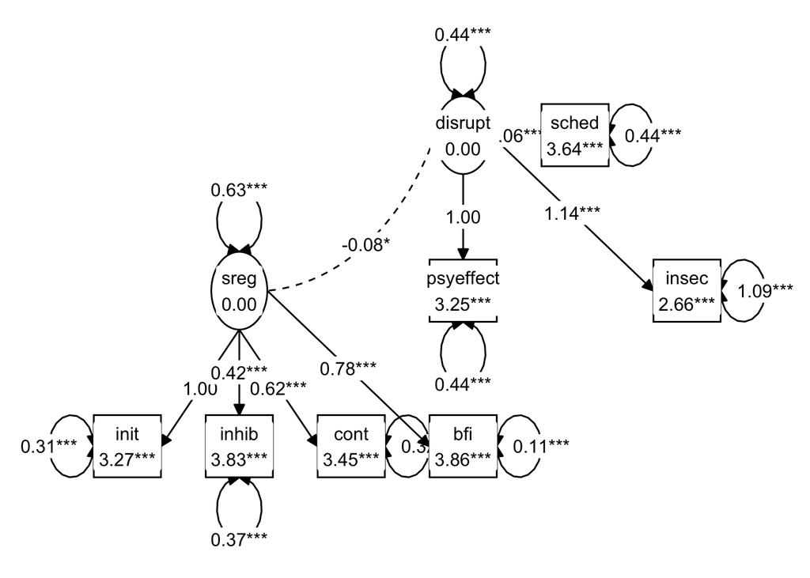

```r
graph_sem(model = habit.fit)
```

# Request output

```r
lavaan::summary(habit.fit, # sem model name
                fit.measures = TRUE, #request fit stats
                standardized = TRUE) #request std output
```

```
## lavaan 0.6-18 ended normally after 42 iterations
##
##   Estimator                                         ML
##   Optimization method                           NLMINB
##   Number of model parameters                        22
##
##   Number of observations                           432
##   Number of missing patterns                         2
##
## Model Test User Model:
##                                               Standard      Scaled
##   Test Statistic                                27.937      26.585
##   Degrees of freedom                                13          13
##   P-value (Chi-square)                           0.009       0.014
##   Scaling correction factor                                  1.051
##     Yuan-Bentler correction (Mplus variant)
##
## Model Test Baseline Model:
##
##   Test statistic                               888.350     788.813
##   Degrees of freedom                                21          21
##   P-value                                        0.000       0.000
##   Scaling correction factor                                  1.126
##
## User Model versus Baseline Model:
##
##   Comparative Fit Index (CFI)                    0.983       0.982
##   Tucker-Lewis Index (TLI)                       0.972       0.971
##
##   Robust Comparative Fit Index (CFI)                         0.983
##   Robust Tucker-Lewis Index (TLI)                            0.973
##
## Loglikelihood and Information Criteria:
##
##   Loglikelihood user model (H0)              -3481.843   -3481.843
##   Scaling correction factor                                  1.004
##       for the MLR correction
##   Loglikelihood unrestricted model (H1)      -3467.874   -3467.874
##   Scaling correction factor                                  1.021
##       for the MLR correction
```

[output cut: 52 more lines]

```
##    .inhib             3.826    0.033  114.233    0.000    3.826    5.496
##    .cont              3.448    0.036   96.077    0.000    3.448    4.623
##    .bfi               3.861    0.034  113.981    0.000    3.861    5.484
##
## Variances:
##                    Estimate  Std.Err  z-value  P(>|z|)   Std.lv  Std.all
##    .psyeffect         0.437    0.052    8.385    0.000    0.437    0.496
##    .sched             0.444    0.069    6.395    0.000    0.444    0.470
##    .insec             1.093    0.102   10.693    0.000    1.093    0.655
##    .init              0.311    0.035    8.839    0.000    0.311    0.331
##    .inhib             0.373    0.025   15.036    0.000    0.373    0.770
##    .cont              0.318    0.029   11.128    0.000    0.318    0.572
##    .bfi               0.112    0.020    5.669    0.000    0.112    0.225
##     disrupt           0.445    0.064    6.975    0.000    1.000    1.000
##     sreg              0.628    0.059   10.729    0.000    1.000    1.000
```

Intercepts with a . before the variable name are observed intercepts, as none of these are latent variables Variances with a . are residual variances of the observed variables in this case Variance without a . are the latent variable variances

# Use lavInspect to check model parameters and matrices

## Sample statistics (of observed variables)

```r
lavInspect(habit.fit, what = "sampstat")
```

```
## $cov
##           psyffc  sched  insec   init  inhib   cont    bfi
## psyeffect  0.882
## sched      0.476  0.944
## insec      0.492  0.539  1.668
## init      -0.096 -0.028 -0.187  0.939
## inhib     -0.046 -0.038 -0.053  0.255  0.485
## cont      -0.085 -0.023 -0.129  0.374  0.211  0.556
## bfi       -0.057 -0.007 -0.153  0.496  0.197  0.300  0.496
##
## $mean
## psyeffect     sched     insec      init     inhib      cont       bfi
##     3.251     3.641     2.661     3.270     3.826     3.448     3.861
```

## Model implied correlation matrices

Of latent variables:

Model implied vcov matrix of latent variables:

```r
lavInspect(habit.fit, what = "cor.lv")
```

```
##         disrpt   sreg
## disrupt  1.000
## sreg    -0.144  1.000
```

Use cov.lv to get the covariance matrix.

Of observed variables:

```r
lavInspect(habit.fit, what = "cor.ov")
```

```
##           psyffc  sched  insec   init  inhib   cont    bfi
## psyeffect  1.000
## sched      0.517  1.000
## insec      0.417  0.427  1.000
## init      -0.083 -0.085 -0.069  1.000
## inhib     -0.049 -0.050 -0.040  0.392  1.000
## cont      -0.067 -0.068 -0.055  0.535  0.314  1.000
## bfi       -0.090 -0.092 -0.074  0.720  0.422  0.576  1.000
```

Use cov.ov to get the covariance matrix.

For all variables in model:

```r
lavInspect(habit.fit, what = "cor.all")
```

```
##           psyffc  sched  insec   init  inhib   cont    bfi disrpt   sreg
## psyeffect  1.000
## sched      0.517  1.000
## insec      0.417  0.427  1.000
## init      -0.083 -0.085 -0.069  1.000
## inhib     -0.049 -0.050 -0.040  0.392  1.000
## cont      -0.067 -0.068 -0.055  0.535  0.314  1.000
## bfi       -0.090 -0.092 -0.074  0.720  0.422  0.576  1.000
## disrupt    0.710  0.728  0.587 -0.117 -0.069 -0.094 -0.126  1.000
## sreg      -0.102 -0.104 -0.084  0.818  0.479  0.654  0.880 -0.144  1.000
```

Look at the correlations between the latent variables and their indicators. They are identical to the standardized loadings. That’s because these loadings are the correlation between the observed variable and their latent factor. This value, when squared, is the amount of variance of the indicator that is explained by the latent construct. Check below.

```r
lavInspect(habit.fit, what = "rsquare")
```

```
## psyeffect     sched     insec      init     inhib      cont       bfi
##     0.504     0.530     0.345     0.669     0.230     0.428     0.775
```

## Starting values

```r
lavInspect(habit.fit, what = "starting.values")
```

```
## $lambda
##           disrpt  sreg
## psyeffect  1.000 0.000
## sched      1.097 0.000
## insec      1.132 0.000
## init       0.000 1.000
## inhib      0.000 0.422
## cont       0.000 0.621
## bfi        0.000 0.796
##
## $theta
##           psyffc sched insec  init inhib  cont   bfi
## psyeffect  0.441
## sched      0.000 0.472
## insec      0.000 0.000 0.834
## init       0.000 0.000 0.000 0.469
## inhib      0.000 0.000 0.000 0.000 0.242
## cont       0.000 0.000 0.000 0.000 0.000 0.278
## bfi        0.000 0.000 0.000 0.000 0.000 0.000 0.248
##
## $psi
##         disrpt sreg
## disrupt   0.05
## sreg      0.00 0.05
##
## $nu
##           intrcp
## psyeffect  3.251
## sched      3.641
## insec      2.661
## init       3.270
## inhib      3.826
## cont       3.448
## bfi        3.861
##
## $alpha
##         intrcp
## disrupt      0
## sreg         0
```

## Estimated parameters in matrix format

```r
lavInspect(habit.fit, what = "est")
```

```
## $lambda
##           disrpt  sreg
## psyeffect  1.000 0.000
## sched      1.060 0.000
## insec      1.137 0.000
## init       0.000 1.000
## inhib      0.000 0.421
## cont       0.000 0.616
## bfi        0.000 0.782
##
## $theta
##           psyffc sched insec  init inhib  cont   bfi
## psyeffect  0.437
## sched      0.000 0.444
## insec      0.000 0.000 1.093
## init       0.000 0.000 0.000 0.311
## inhib      0.000 0.000 0.000 0.000 0.373
## cont       0.000 0.000 0.000 0.000 0.000 0.318
## bfi        0.000 0.000 0.000 0.000 0.000 0.000 0.112
##
## $psi
##         disrpt   sreg
## disrupt  0.445
## sreg    -0.076  0.628
##
## $nu
##           intrcp
## psyeffect  3.251
## sched      3.641
## insec      2.661
## init       3.270
## inhib      3.826
## cont       3.448
## bfi        3.861
##
## $alpha
##         intrcp
## disrupt      0
## sreg         0
```

## Standardized estimated parameters in matrix format

```r
lavInspect(habit.fit, what = "std")
```

```
## $lambda
##           disrpt  sreg
## psyeffect  0.710 0.000
## sched      0.728 0.000
## insec      0.587 0.000
## init       0.000 0.818
## inhib      0.000 0.479
## cont       0.000 0.654
## bfi        0.000 0.880
##
## $theta
##           psyffc sched insec  init inhib  cont   bfi
## psyeffect  0.496
## sched      0.000 0.470
## insec      0.000 0.000 0.655
## init       0.000 0.000 0.000 0.331
## inhib      0.000 0.000 0.000 0.000 0.770
## cont       0.000 0.000 0.000 0.000 0.000 0.572
## bfi        0.000 0.000 0.000 0.000 0.000 0.000 0.225
##
## $psi
##         disrpt   sreg
## disrupt  1.000
## sreg    -0.144  1.000
##
## $nu
##           intrcp
## psyeffect  3.461
## sched      3.747
## insec      2.060
## init       3.375
## inhib      5.496
## cont       4.623
## bfi        5.484
##
## $alpha
##         intrcp
## disrupt      0
## sreg         0
```

Same as above, but the variances of the latent variables are set to 1.0

```r
lavInspect(habit.fit, what = "std.lv")
```

```
## $lambda
##           disrpt  sreg
## psyeffect  0.667 0.000
## sched      0.707 0.000
## insec      0.758 0.000
## init       0.000 0.793
## inhib      0.000 0.334
## cont       0.000 0.488
## bfi        0.000 0.620
##
## $theta
##           psyffc sched insec  init inhib  cont   bfi
## psyeffect  0.437
## sched      0.000 0.444
## insec      0.000 0.000 1.093
## init       0.000 0.000 0.000 0.311
## inhib      0.000 0.000 0.000 0.000 0.373
## cont       0.000 0.000 0.000 0.000 0.000 0.318
## bfi        0.000 0.000 0.000 0.000 0.000 0.000 0.112
##
## $psi
##         disrpt   sreg
## disrupt  1.000
## sreg    -0.144  1.000
##
## $nu
##           intrcp
## psyeffect  3.251
## sched      3.641
## insec      2.661
## init       3.270
## inhib      3.826
## cont       3.448
## bfi        3.861
##
## $alpha
##         intrcp
## disrupt      0
## sreg         0
```

## Inspect missing data patterns

```r
lavInspect(habit.fit, what = "patterns")
```

```
##      psyffc sched insec init inhib cont bfi
## [1,]      1     1     1    1     1    1   1
## [2,]      1     1     0    1     1    1   1
```

Note that we have two patterns: One where there’s no missing data, and one where there’s missing data in the insecurity variable

Also check coverage: Proportion of observed data points for a pair of observed variables.

```r
lavInspect(habit.fit, what = "coverage")
```

```
##           psyffc sched insec  init inhib  cont   bfi
## psyeffect  1.000
## sched      1.000 1.000
## insec      0.998 0.998 0.998
## init       1.000 1.000 0.998 1.000
## inhib      1.000 1.000 0.998 1.000 1.000
## cont       1.000 1.000 0.998 1.000 1.000 1.000
## bfi        1.000 1.000 0.998 1.000 1.000 1.000 1.000
```

# Practice

1. Using the lavaan cheat sheet or the slides from class, how would you specify model habit.sem so that the first loadings of the latent variables are freely estimated? Estimate the model and check how it compares with the diagram above when “stand = TRUE.”
2. How would you change the model above to add covariances between the indicators of self-regulation? Estimate the model and check the output. How does fit change?
3. How many parameters are being estimated in each model? Why has the number changed (what has remained constant and what has changed)?